# iii_case3

2024-11-17

## Tushar Yadav & Vatsal Nanawati - Section 1

## Interpretation :

### Model Free Analysis & Correlation Between Endogenous Variables and Instruments

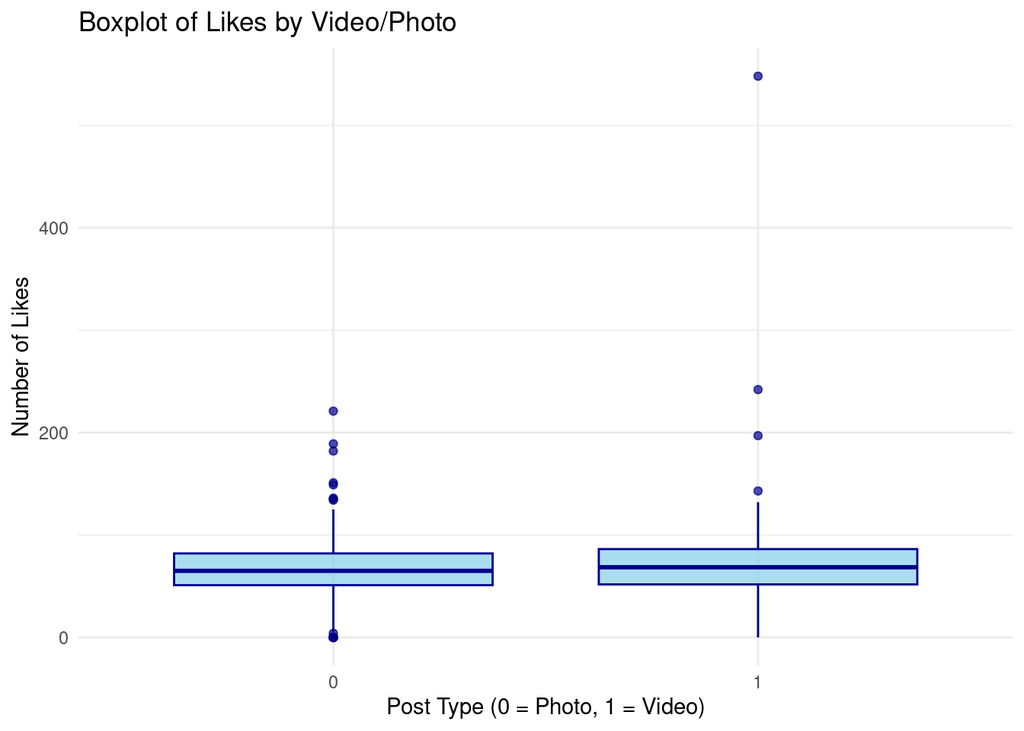

```r
load("HW3.Rdata")
library(ggplot2)

## boxplot for Likes vs Video
ggplot(IGdata, aes(x = factor(Video), y = IGLikes)) +
  geom_boxplot(fill = "skyblue", color = "darkblue", alpha = 0.7) +
  labs(title = "Boxplot of Likes by Video/Photo", x = "Post Type (0 = Photo, 1 = Video)", y = "Number of Likes") +
  theme_minimal()
```

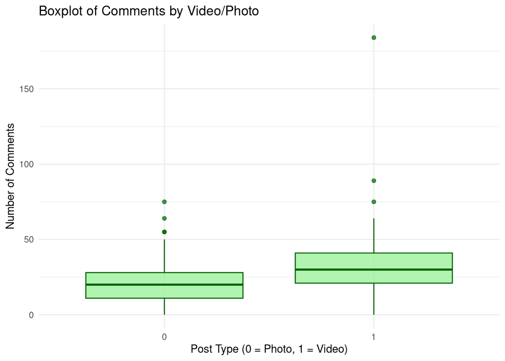

```r
## boxplot for Comments vs Video
ggplot(IGdata, aes(x = factor(Video), y = IGComments)) +
  geom_boxplot(fill = "lightgreen", color = "darkgreen", alpha = 0.7) +
  labs(title = "Boxplot of Comments by Video/Photo", x = "Post Type (0 = Photo, 1 = Video)", y = "Number of Comments") +
  theme_minimal()
```

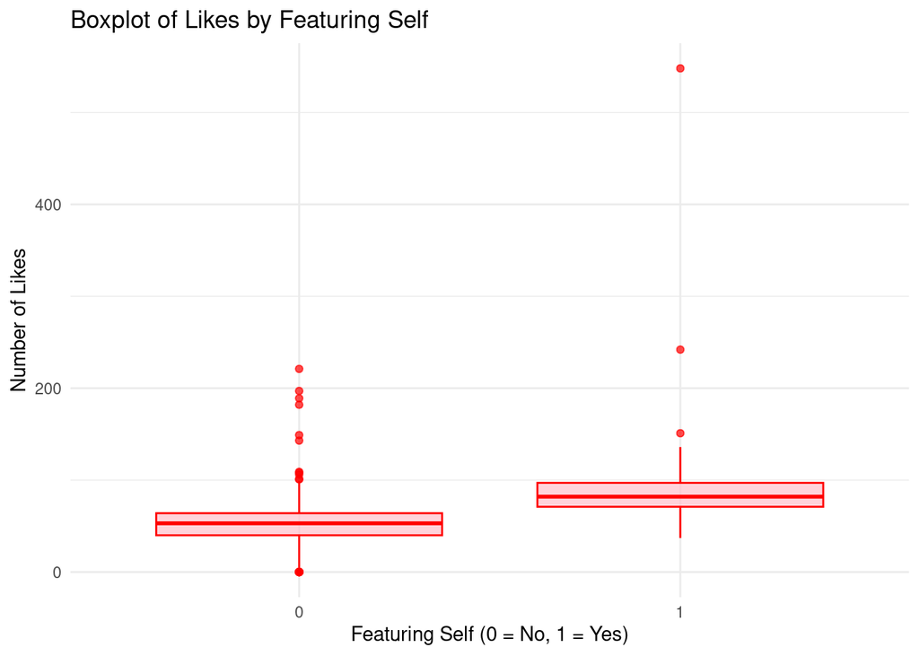

```r
## boxplot for Likes vs Featuring Self
ggplot(IGdata, aes(x = factor(FeatureSelf), y = IGLikes)) +
  geom_boxplot(fill = "pink", color = "red", alpha = 0.7) +
  labs(title = "Boxplot of Likes by Featuring Self", x = "Featuring Self (0 = No, 1 = Yes)", y = "Number of Likes") +
  theme_minimal()
```

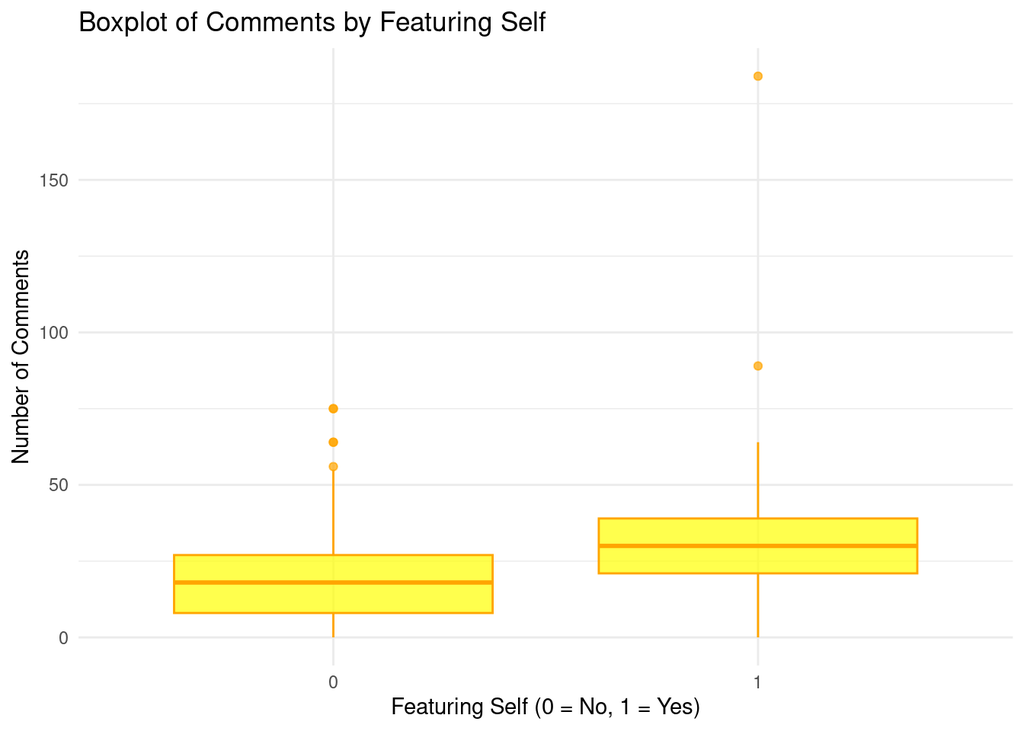

```r
## boxplot for Comments vs Featuring Self
ggplot(IGdata, aes(x = factor(FeatureSelf), y = IGComments)) +
  geom_boxplot(fill = "yellow", color = "orange", alpha = 0.7) +
  labs(title = "Boxplot of Comments by Featuring Self", x = "Featuring Self (0 = No, 1 = Yes)", y = "Number of Comments") +
  theme_minimal()
```

```r
## correlation between 'Video' and 'Photography'
cor_vp <- cor(IGdata$Video, IGdata$Photography)
cor_vp
```

```
## [1] -0.4487178
```

```r
## correlation between 'FeatureSelf' and 'SelfPct'
cor_fs <- cor(IGdata$FeatureSelf, IGdata$SelfPct)
cor_fs
```

```
## [1] 0.6473412
```

### First Stage Regressions (Regress Endogenous Variables on Instruments)

```r
## 1) Regress 'Video' on 'Photography' (Instrument for 'Video')
first_stage_video <- lm(Video ~ Photography, data = IGdata)
## Extract fitted values (X_hat for Video)
Video_hat <- fitted.values(first_stage_video)

## 2) Regress 'FeatureSelf' on 'SelfPct' (Instrument for 'FeatureSelf')
first_stage_self <- lm(FeatureSelf ~ SelfPct, data = IGdata)
## Extract fitted values (X_hat for FeatureSelf)
FeatureSelf_hat <- fitted.values(first_stage_self)
```

### Second Stage Regressions (Regress Engagements on the Instruments)

```r
## 1) Regress IGLikes on 'Followers', 'LengthChar', 'Video_hat', and 'FeatureSelf_hat'
second_stage_likes <- lm(IGLikes ~ Followers + LengthChar + Video_hat + FeatureSelf_hat, data = IGdata)
summary(second_stage_likes)
```

```
##
## Call:
## lm(formula = IGLikes ~ Followers + LengthChar + Video_hat + FeatureSelf_hat,
##     data = IGdata)
##
## Residuals:
##     Min      1Q  Median      3Q     Max
## -56.131 -14.896   0.145  13.335  66.755
##
## Coefficients:
##                 Estimate Std. Error t value Pr(>|t|)
## (Intercept)     10.17142    3.31284   3.070   0.0022 **
## Followers        0.10379    0.00343  30.265   <2e-16 ***
## LengthChar       0.04272    0.02561   1.668   0.0956 .
## Video_hat       -6.03862    3.04003  -1.986   0.0473 *
## FeatureSelf_hat 35.47321    2.05820  17.235   <2e-16 ***
## ---
## Signif. codes:  0 '***' 0.001 '**' 0.01 '*' 0.05 '.' 0.1 ' ' 1
##
## Residual standard error: 21 on 995 degrees of freedom
## Multiple R-squared:  0.5482, Adjusted R-squared:  0.5464
## F-statistic: 301.8 on 4 and 995 DF,  p-value: < 2.2e-16
```

```r
## 2) Regress IGComments on 'Followers', 'LengthChar', 'Video_hat', and 'FeatureSelf_hat'
second_stage_comments <- lm(IGComments ~ Followers + LengthChar + Video_hat + FeatureSelf_hat, data = IGdata)
summary(second_stage_comments)
```

```
##
## Call:
## lm(formula = IGComments ~ Followers + LengthChar + Video_hat +
##     FeatureSelf_hat, data = IGdata)
##
## Residuals:
##     Min      1Q  Median      3Q     Max
## -33.670 -10.033  -0.144   9.311  39.743
##
## Coefficients:
##                 Estimate Std. Error t value Pr(>|t|)
## (Intercept)     1.613922   2.133224   0.757  0.44949
## Followers       0.033797   0.002208  15.304  < 2e-16 ***
## LengthChar      0.049385   0.016493   2.994  0.00282 **
## Video_hat       8.877261   1.957556   4.535 6.47e-06 ***
## FeatureSelf_hat 3.280119   1.325328   2.475  0.01349 *
## ---
## Signif. codes:  0 '***' 0.001 '**' 0.01 '*' 0.05 '.' 0.1 ' ' 1
##
## Residual standard error: 13.53 on 995 degrees of freedom
## Multiple R-squared:  0.2133, Adjusted R-squared:  0.2102
## F-statistic: 67.45 on 4 and 995 DF,  p-value: < 2.2e-16
```

### OLS Regression (Regress Engagements on Endogenous Variables Directly)

```r
## 1) OLS Regression for Likes
ols_likes <- lm(IGLikes ~ Followers + LengthChar + Video + FeatureSelf, data = IGdata)
summary(ols_likes)
```

```
##
## Call:
## lm(formula = IGLikes ~ Followers + LengthChar + Video + FeatureSelf,
##     data = IGdata)
##
## Residuals:
##    Min     1Q Median     3Q    Max
## -53.57 -11.81   0.73  11.77  51.21
##
## Coefficients:
##              Estimate Std. Error t value Pr(>|t|)
## (Intercept)  9.553123   2.509106   3.807 0.000149 ***
## Followers    0.103185   0.002857  36.117  < 2e-16 ***
## LengthChar   0.030900   0.021329   1.449 0.147725
## Video        2.569818   1.135884   2.262 0.023888 *
## FeatureSelf 32.656932   1.110217  29.415  < 2e-16 ***
## ---
## Signif. codes:  0 '***' 0.001 '**' 0.01 '*' 0.05 '.' 0.1 ' ' 1
##
## Residual standard error: 17.49 on 995 degrees of freedom
## Multiple R-squared:  0.6866, Adjusted R-squared:  0.6853
## F-statistic: 544.9 on 4 and 995 DF,  p-value: < 2.2e-16
```

```r
## 2) OLS Regression for Comments
ols_comments <- lm(IGComments ~ Followers + LengthChar + Video + FeatureSelf, data = IGdata)
summary(ols_comments)
```

```
##
## Call:
## lm(formula = IGComments ~ Followers + LengthChar + Video + FeatureSelf,
##     data = IGdata)
##
## Residuals:
##      Min       1Q   Median       3Q      Max
## -30.5875  -8.5759  -0.0175   7.3343  31.1792
##
## Coefficients:
##              Estimate Std. Error t value Pr(>|t|)
## (Intercept) -1.719642   1.572862  -1.093   0.2745
## Followers    0.033275   0.001791  18.580   <2e-16 ***
## LengthChar   0.034397   0.013370   2.573   0.0102 *
## Video       11.445260   0.712042  16.074   <2e-16 ***
## FeatureSelf 11.900400   0.695952  17.099   <2e-16 ***
## ---
## Signif. codes:  0 '***' 0.001 '**' 0.01 '*' 0.05 '.' 0.1 ' ' 1
##
## Residual standard error: 10.97 on 995 degrees of freedom
## Multiple R-squared:  0.4828, Adjusted R-squared:  0.4807
## F-statistic: 232.2 on 4 and 995 DF,  p-value: < 2.2e-16
```

### Instrumental Variables Regression

```r
install.packages('ivreg')
```

```r
library(ivreg)

## 1) IV regression for IGLikes (instrumenting Video and FeatureSelf)
iv_likes <- ivreg(IGLikes ~ Followers + LengthChar + Video + FeatureSelf | Followers + LengthChar + Photography + SelfPct, data = IGdata)
summary(iv_likes)
```

```
##
## Call:
## ivreg(formula = IGLikes ~ Followers + LengthChar + Video + FeatureSelf |
##     Followers + LengthChar + Photography + SelfPct, data = IGdata)
##
## Residuals:
##      Min       1Q   Median       3Q      Max
## -56.9920 -12.0585   0.2401  11.3731  54.5992
##
## Coefficients:
##              Estimate Std. Error t value Pr(>|t|)
## (Intercept) 12.578877   2.860386   4.398 1.21e-05 ***
## Followers    0.103785   0.002966  34.993  < 2e-16 ***
## LengthChar   0.032827   0.022190   1.479   0.1394
## Video       -7.262961   2.587628  -2.807   0.0051 **
## FeatureSelf 33.450827   1.905693  17.553  < 2e-16 ***
##
## Diagnostic tests:
##                                df1 df2 statistic  p-value
## Weak instruments (Video)         2 995    155.09  < 2e-16 ***
## Weak instruments (FeatureSelf)   2 995    358.19  < 2e-16 ***
## Wu-Hausman                       2 993     15.54 2.26e-07 ***
## Sargan                           0  NA        NA       NA
## ---
## Signif. codes:  0 '***' 0.001 '**' 0.01 '*' 0.05 '.' 0.1 ' ' 1
##
## Residual standard error: 18.14 on 995 degrees of freedom
## Multiple R-Squared: 0.6629,  Adjusted R-squared: 0.6615
## Wald test: 404.5 on 4 and 995 DF,  p-value: < 2.2e-16
```

```r
## 2) IV regression for IGComments (instrumenting Video and FeatureSelf)
iv_comments <- ivreg(IGComments ~ Followers + LengthChar + Video + FeatureSelf | Followers + LengthChar + Photography + SelfPct, data = IGdata)
summary(iv_comments)
```

```
##
## Call:
## ivreg(formula = IGComments ~ Followers + LengthChar + Video +
##     FeatureSelf | Followers + LengthChar + Photography + SelfPct,
##     data = IGdata)
##
## Residuals:
##       Min        1Q    Median        3Q       Max
## -31.76605  -8.44516  -0.01403   7.80890  30.34749
##
## Coefficients:
##             Estimate Std. Error t value Pr(>|t|)
## (Intercept) 1.595004   1.809603   0.881  0.37831
## Followers   0.033371   0.001876  17.785  < 2e-16 ***
## LengthChar  0.040637   0.014038   2.895  0.00388 **
## Video       8.621388   1.637045   5.266 1.70e-07 ***
## FeatureSelf 5.742178   1.205623   4.763 2.19e-06 ***
##
## Diagnostic tests:
##                                df1 df2 statistic  p-value
## Weak instruments (Video)         2 995    155.09  < 2e-16 ***
## Weak instruments (FeatureSelf)   2 995    358.19  < 2e-16 ***
## Wu-Hausman                       2 993     24.98 2.61e-11 ***
## Sargan                           0  NA        NA       NA
## ---
## Signif. codes:  0 '***' 0.001 '**' 0.01 '*' 0.05 '.' 0.1 ' ' 1
##
## Residual standard error: 11.48 on 995 degrees of freedom
## Multiple R-Squared: 0.4334,  Adjusted R-squared: 0.4311
## Wald test: 93.64 on 4 and 995 DF,  p-value: < 2.2e-16
```

### Comparison:

```r
library(knitr)
library(kableExtra)

## creating the data frame with the comparison results
comparison_table <- data.frame(
  Model = c("Video", "FeatureSelf", "Followers", "LengthChar"),
  OLS = c("2.57", "32.66", "0.10", "0.03"),
  IV = c("-7.26", "33.45", "0.10", "0.03"),
  OLS = c("11.45", "11.90", "0.03", "0.03"),
  IV = c("8.62", "5.74", "0.03", "0.04")
)
kable(comparison_table, , caption = "Comparison of OLS and IV Regression Results for Likes and Comments", format = "html", align = "c", col.names = c(
  "Model",
  "OLS", "IV",
  "OLS", "IV"
)) %>%
  add_header_above(c(" " = 1, "Likes" = 2, "Comments" = 2)) %>%
  kable_styling(full_width = F, bootstrap_options = c("striped", "hover", "condensed", "bordered"))
```

Comparison of OLS and IV Regression Results for Likes and Comments

| Model | Likes OLS | Likes IV | Comments OLS | Comments IV |
| --- | --- | --- | --- | --- |
| Video | 2.57 | -7.26 | 11.45 | 8.62 |
| FeatureSelf | 32.66 | 33.45 | 11.90 | 5.74 |
| Followers | 0.10 | 0.10 | 0.03 | 0.03 |
| LengthChar | 0.03 | 0.03 | 0.03 | 0.04 |